# What did presidents react towards recessions?

Jing Zhao jz2786

The word “Recessions” always makes people feel desperate and painful. However, assume recession happens or is happening when a nominee is running for president, what would he or she think? Will he/she feel fear? Or in contrast, will the recession just stimulate he/she to generate a sense of mission.

I pick up 6 periods of recession. All these recessions just happened during the elections. They are Panic of 1873, 1882-85 recession, depression of 1920-21, 1929 great depression, 1980 recession and 2007 great depression. Accordingly, these presidents are Rutherford B. Hayes, Grover Cleveland, Warren G. Harding, Franklin D. Roosevelt, Ronald Reagan and Barack Obama.

I will use sentiment analysis and topic models to analyze what kind of emotions presidents during recession time deliver and whether they pay more attention on economics related topics.

## 1. Preparation: install and load packages

```r
packages.used=c("rvest", "tibble", "qdap",
                "sentimentr", "gplots", "dplyr",
                "tm", "syuzhet", "factoextra",
                "beeswarm", "scales", "RColorBrewer",
                "RANN", "tm", "topicmodels")

# check packages that need to be installed.
packages.needed=setdiff(packages.used,
                        intersect(installed.packages()[,1],
                                  packages.used))
# install additional packages
if(length(packages.needed)>0){
  install.packages(packages.needed, dependencies = TRUE)
}
install.packages("tidytext",dependencies=TRUE,repos='http://cran.rstudio.com/')
# load packages
library("rvest")
library("tibble")
# You may need to run
# sudo ln -f -s $(/usr/libexec/java_home)/jre/lib/server/libjvm.dylib /usr/local/lib
# in order to load qdap
library("qdap")
library("sentimentr")
library("gplots")
library("dplyr")
library("tm")
library("syuzhet")
library("factoextra")
library("beeswarm")
library("scales")
library("RColorBrewer")
library("RANN")
library("tm")
library("topicmodels")

source("../lib/plotstacked.R")
source("../lib/speechFuncs.R")
```

```r
print(R.version)
```

```
##                _
## platform       x86_64-apple-darwin13.4.0
## arch           x86_64
## os             darwin13.4.0
## system         x86_64, darwin13.4.0
## status
## major          3
## minor          3.3
## year           2017
## month          03
## day            06
## svn rev        72310
## language       R
## version.string R version 3.3.3 (2017-03-06)
## nickname       Another Canoe
```

## 2. Data for Sentiment Analysis

```r
inaug.folder.path="../data/fulltext/"

inaug.all.speeches=list.files(path = inaug.folder.path, pattern ="^inaug.*\\.txt$")
inaug.all.list=read.csv("../data/inauglist.csv", stringsAsFactors = FALSE)
speech.all.list = inaug.all.list
speech.all.list$type=rep("inaug", nrow(inaug.all.list))
for(i in seq(nrow(speech.all.list))){
  speech.all.list$fulltext[i] =
    readLines(paste("../data/fulltext/",inaug.all.speeches[i],sep=''),
                                          n=-1, skipNul=TRUE)
}
```

```r
presidents.recession=c("BarackObama","FranklinDRoosevelt","GroverCleveland","RonaldReagan","RutherfordBHayes","WarrenGHarding")
sentence.list=NULL
for(i in 1:nrow(speech.all.list)){
  sentences=sent_detect(speech.all.list$fulltext[i],
                        endmarks = c("?", ".", "!", "|",";"))
  if(length(sentences)>0){
    emotions=get_nrc_sentiment(sentences)
    word.count=word_count(sentences)
    # colnames(emotions)=paste0("emo.", colnames(emotions))
    # in case the word counts are zeros?
    emotions=diag(1/(word.count+0.01))%*%as.matrix(emotions)
    sentence.list=rbind(sentence.list,
                        cbind(speech.all.list[i,-ncol(speech.all.list)],
                              sentences=as.character(sentences),
                              word.count,
                              emotions,
                              sent.id=1:length(sentences)
                              )
    )
  }
}
sentence.list=
  sentence.list%>%
  filter(!is.na(word.count))
```

## 3. Comparsion with recession background

Here I am going to compare sentiments in inaugurals between presidents during recessions and the remaining presidents.

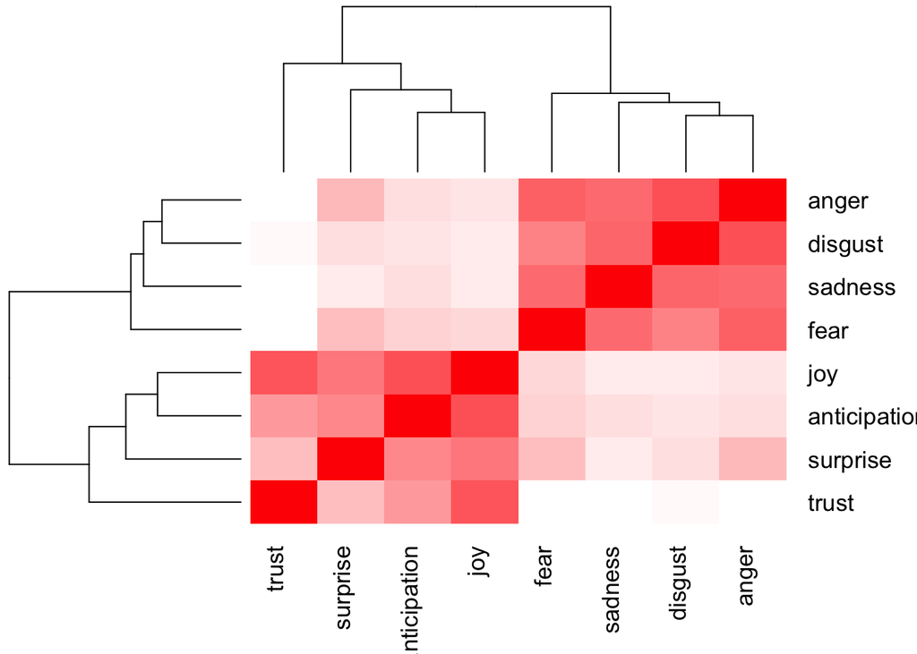

```r
presidents.normal = setdiff(speech.all.list$File,presidents.recession)

heatmap.2(cor(sentence.list%>%filter(type=="inaug", File%in%presidents.recession)%>%select(anger:trust)),
          scale = "none",
          col = bluered(100), , margin=c(6, 6), key=F,
          trace = "none", density.info = "none")
```

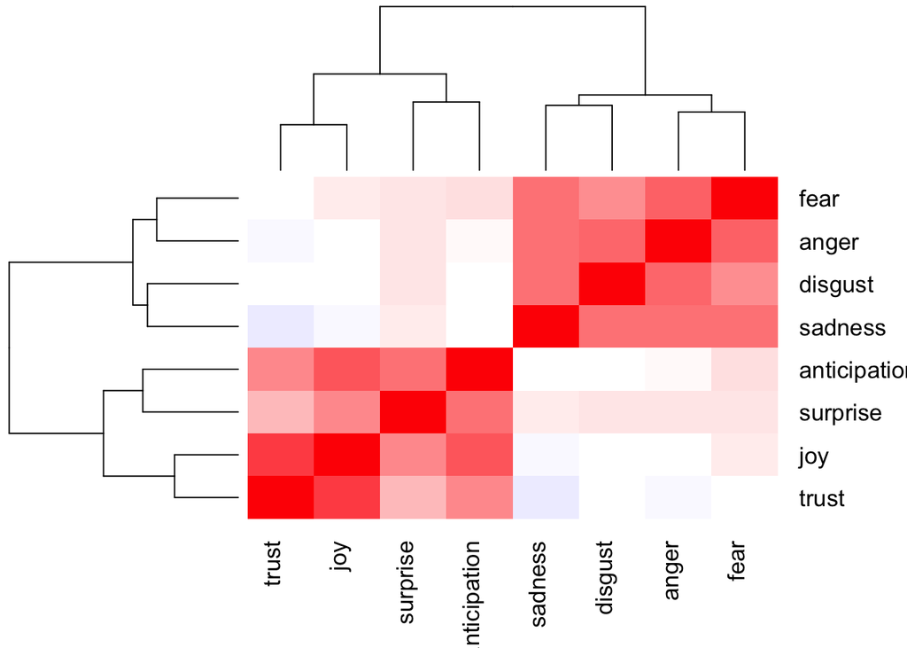

```r
heatmap.2(cor(sentence.list%>%filter(type=="inaug",File%in%presidents.normal)%>%select(anger:trust)),
          scale = "none",
          col = bluered(100), , margin=c(6, 6), key=F,
          trace = "none", density.info = "none")
```

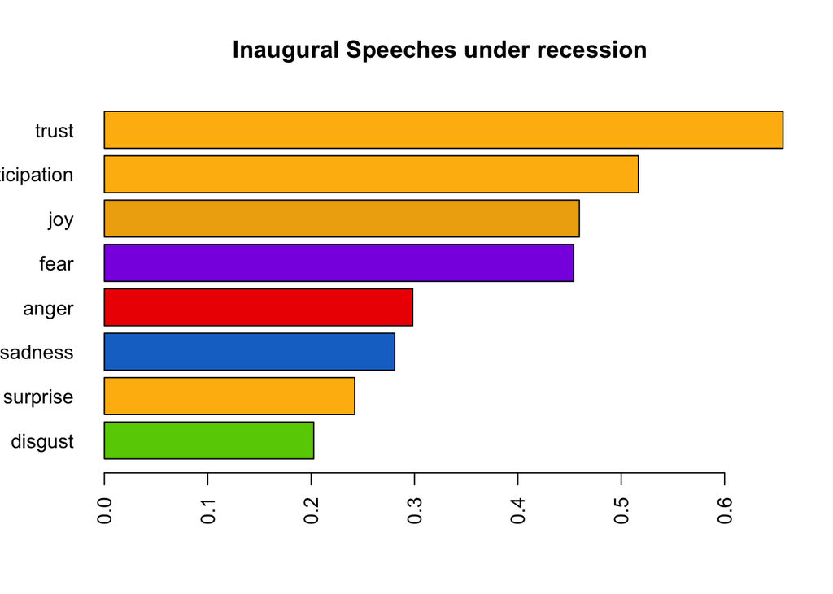

```r
emo.means.recession=colMeans(select(sentence.list%>%filter(type=="inaug",File%in%presidents.recession), anger:trust)>0.01)
col.use=c("red2", "darkgoldenrod1",
            "chartreuse3", "blueviolet",
            "darkgoldenrod2", "dodgerblue3",
            "darkgoldenrod1", "darkgoldenrod1")
barplot(emo.means.recession[order(emo.means.recession)], las=2, col=col.use[order(emo.means.recession)], horiz=T, main="Inaugural Speeches under recession")
```